# Introduction to the Isosceles package

Michal Kabza, Tim Sterne-Weiler

17 July 2023

#### Package

Isosceles 0.0.0.9000

# 1 Introduction

Isosceles (**Iso**form **S**ingle-**Ce**ll and **L**ong-read **E**xpression **S**uite) is an R package dedicated to transcript detection and quantification from ONT reads, supporting both bulk RNA-Seq and scRNA-Seq technologies.

Isosceles can be installed using the following commands:

```r
# Install Bioconductor dependencies (basic installation)
BiocManager::install(c("scuttle", "GenomicFeatures", "BSgenome"))
# Install Bioconductor dependencies (building the vignette)
BiocManager::install(c("dittoSeq", "ggbio", "BiocStyle"))
# Install Isosceles
devtools::install_github('timbitz/Isosceles')
```

Load the Isosceles package:

```r
library(Isosceles)
```

# 2 Input data

Isosceles requires the following input files:

- BAM file(s) containing aligned ONT reads and (for scRNA-Seq data) cell barcode tags
  - We recommend minimap2 for bulk RNA-Seq data and [Sicelore](https://github.com/ucagenomix/sicelore) for scRNA-Seq data
- FASTA file containing the genomic sequences
- GTF file containing the genomic annotations

# 3 Run modes

Isosceles can used in of the following run modes:

- **strict** - only annotated reference transcripts will be quantified
- **de_novo_strict** - de novo transcripts whose all splice sites are known (i.e. found in reference annotations or provided by the user) are also included
- **de_novo_loose** - de novo transcripts whose all splice sites are reproducibly passing filters in the aligned reads are included as well

# 4 Bulk RNA-Seq analysis

Get the input file paths:

```r
bam_file <- system.file(
  "extdata", "SGNex_A549_directRNA_replicate5_run1_chr9_1_1000000.bam",
  package = "Isosceles"
)
gtf_file <- system.file(
  "extdata", "Homo_sapiens.GRCh38.91_chr9_1_1000000.gtf",
  package = "Isosceles"
)
genome_fasta_file <- system.file(
  "extdata", "Homo_sapiens.GRCh38.dna_sm.primary_assembly_chr9_1_1000000.fa",
  package = "Isosceles"
)
```

Extract read data from the BAM files:

```r
bam_files <- c(Sample = bam_file)
bam_parsed <- extract_read_structures(
    bam_files = bam_files
)
```

Prepare transcript data for the analysis:

```r
transcript_data <- prepare_transcripts(
    gtf_file = gtf_file,
    genome_fasta_file = genome_fasta_file,
    bam_parsed = bam_parsed,
    min_bam_splice_read_count = 2,
    min_bam_splice_fraction = 0.01
)
```

Create a TCC (Transcript Compatibility Counts) SummarizedExperiment object:

```r
se_tcc <- prepare_tcc_se(
    bam_files = bam_files,
    transcript_data = transcript_data,
    run_mode = "de_novo_loose",
    min_read_count = 1,
    min_relative_expression = 0
)
se_tcc
## class: SummarizedExperiment
## dim: 45 1
## metadata(4): compatibility_matrix transcript_df
##   transcript_exon_granges_list mean_read_length
## assays(3): counts tpm relative_expression
## rownames(45): 20,22,24,25,26,27 20,23,24,25,26,27,28 ... 74 75
## rowData names(3): ec_id gene_id gene_name
## colnames(1): Sample
## colData names(0):
```

Create a transcript-level SummarizedExperiment object:

```r
se_transcript <- prepare_transcript_se(
    se_tcc = se_tcc,
    use_length_normalization = TRUE
)
se_transcript
## class: RangedSummarizedExperiment
## dim: 117 1
## metadata(0):
## assays(3): counts tpm relative_expression
## rownames(117): ISOT-5c13-e73a-5003-3c93:s976950:e991750:AP:FL
##   ISOT-0000-0000-0000-0762:s989800:e990350:AP:FL ...
##   ISOT-fd89-a94a-cc11-ef44:s72650:e75300:AP:FL
##   ISOT-0000-0000-0000-0762:s30100:e30300:AP:FL
## rowData names(12): transcript_id position ... read_count
##   relative_expression
## colnames(1): Sample
## colData names(0):
```

Create a gene-level SummarizedExperiment object:

```r
se_gene <- prepare_gene_se(
    se_tcc = se_tcc
)
se_gene
## class: SummarizedExperiment
## dim: 23 1
## metadata(0):
## assays(3): counts tpm relative_expression
## rownames(23): ENSG00000064218 ENSG00000107099 ... ENSG00000277631
##   ENSG00000283921
## rowData names(2): gene_id gene_name
## colnames(1): Sample
## colData names(0):
```

# 5 scRNA-Seq analysis

Get the input file paths:

```r
bam_file <- system.file(
    "extdata", "molecule.tags.GE.bam",
    package = "Isosceles"
)
gtf_file <- system.file(
    "extdata", "chr4.gtf.gz",
    package = "Isosceles"
)
genome_fasta_file <- system.file(
    "extdata", "chr4.fa.gz",
    package = "Isosceles"
)
```

Extract read data from the BAM files:

```r
bam_files <- c(Sample = bam_file)
bam_parsed <- extract_read_structures(
    bam_files = bam_files
)
```

Prepare transcript data for the analysis:

```r
transcript_data <- prepare_transcripts(
    gtf_file = gtf_file,
    genome_fasta_file = genome_fasta_file,
    bam_parsed = bam_parsed,
    min_bam_splice_read_count = 1,
    min_bam_splice_fraction = 0.01
)
```

Create a TCC (Transcript Compatibility Counts) SummarizedExperiment object:

```r
se_tcc <- prepare_tcc_se(
    bam_files = bam_files,
    transcript_data = transcript_data,
    run_mode = "de_novo_loose",
    min_read_count = 1,
    min_relative_expression = 0,
    is_single_cell = TRUE,
    barcode_tag = "BC"
)
se_tcc
## class: SummarizedExperiment
## dim: 8 57
## metadata(4): compatibility_matrix transcript_df
##   transcript_exon_granges_list mean_read_length
## assays(3): counts tpm relative_expression
## rownames(8): 470 470,471,472,473,474,475 ... 476 477
## rowData names(3): ec_id gene_id gene_name
## colnames(57): Sample.CGTAGGCAGAAGGCCT Sample.CTAGCCTTCCTATTCA ...
##   Sample.CCGTTCAAGAGTAAGG Sample.CGGCTAGTCCGTTGCT
## colData names(0):
```

Create a transcript-level SummarizedExperiment object:

```r
se_transcript <- prepare_transcript_se(
    se_tcc = se_tcc[, 1:5], # use only 5 cells for speed
    use_length_normalization = FALSE
)
se_transcript
## class: RangedSummarizedExperiment
## dim: 4111 5
## metadata(0):
## assays(3): counts tpm relative_expression
## rownames(4111): ISOT-7438-e6a0-1dea-329e:s120453200:e120530200:AP:FL
##   ISOT-85c9-224f-fb90-8b49:s120447100:e120530200:AP:FL ...
##   ISOT-0000-0000-0000-3df5:s43834750:e43836550:AP:FL
##   ISOT-f090-cb81-2f39-4fa9:s156254500:e156255400:AP:FL
## rowData names(12): transcript_id position ... read_count
##   relative_expression
## colnames(5): Sample.CGTAGGCAGAAGGCCT Sample.CTAGCCTTCCTATTCA
##   Sample.CCATTCGGTATCGCAT Sample.GCATGATGTGTGCGTC
##   Sample.GGCTGGTAGTGTCCCG
## colData names(0):
```

Create a gene-level SummarizedExperiment object:

```r
se_gene <- prepare_gene_se(
    se_tcc = se_tcc
)
se_gene
## class: SummarizedExperiment
## dim: 2855 57
## metadata(0):
## assays(3): counts tpm relative_expression
## rownames(2855): ENSMUSG00000000085 ENSMUSG00000000409 ...
##   ENSMUSG00000111611 ENSMUSG00000111895
## rowData names(2): gene_id gene_name
## colnames(57): Sample.CGTAGGCAGAAGGCCT Sample.CTAGCCTTCCTATTCA ...
##   Sample.CCGTTCAAGAGTAAGG Sample.CGGCTAGTCCGTTGCT
## colData names(0):
```

Create a pseudobulk TCC SummarizedExperiment object:

```r
set.seed(42)
cell_labels <- sample(1:2, ncol(se_tcc), replace = TRUE)
se_pseudobulk_tcc <- prepare_pseudobulk_se(
    se_tcc = se_tcc,
    cell_labels = cell_labels
)
se_pseudobulk_tcc
## class: SummarizedExperiment
## dim: 8 2
## metadata(4): compatibility_matrix transcript_df
##   transcript_exon_granges_list mean_read_length
## assays(3): counts tpm relative_expression
## rownames(8): 470 470,471,472,473,474,475 ... 476 477
## rowData names(3): ec_id gene_id gene_name
## colnames(2): 1 2
## colData names(0):
```

Create a pseudobulk transcript-level SummarizedExperiment object:

```r
se_pseudobulk_transcript <- prepare_transcript_se(
    se_tcc = se_pseudobulk_tcc,
    use_length_normalization = FALSE
)
se_pseudobulk_transcript
## class: RangedSummarizedExperiment
## dim: 4111 2
## metadata(0):
## assays(3): counts tpm relative_expression
## rownames(4111): ISOT-7438-e6a0-1dea-329e:s120453200:e120530200:AP:FL
##   ISOT-85c9-224f-fb90-8b49:s120447100:e120530200:AP:FL ...
##   ISOT-0000-0000-0000-3df5:s43834750:e43836550:AP:FL
##   ISOT-f090-cb81-2f39-4fa9:s156254500:e156255400:AP:FL
## rowData names(12): transcript_id position ... read_count
##   relative_expression
## colnames(2): 1 2
## colData names(0):
```

Create a pseudobulk gene-level SummarizedExperiment object:

```r
se_pseudobulk_gene <- prepare_gene_se(
    se_tcc = se_pseudobulk_tcc
)
se_pseudobulk_gene
## class: SummarizedExperiment
## dim: 2855 2
## metadata(0):
## assays(3): counts tpm relative_expression
## rownames(2855): ENSMUSG00000000085 ENSMUSG00000000409 ...
##   ENSMUSG00000111611 ENSMUSG00000111895
## rowData names(2): gene_id gene_name
## colnames(2): 1 2
## colData names(0):
```

# 6 PSI analysis

Load a transcript-level SingleCellExperiment object containing expression levels of transcripts of the CAV1 gene across 2,060 cells from a mix of ovarian cancer cell lines:

```r
sce_transcript <- readRDS(system.file("extdata", "sce_transcript_cav1.rds",
                                      package = "Isosceles"))
sce_transcript
## class: SingleCellExperiment
## dim: 6 2060
## metadata(0):
## assays(3): counts tpm relative_expression
## rownames(6): ISOT-187e-bc5a-afe9-5320:s116525000:e116559350:AP:FL
##   ISOT-35a7-317f-81c6-345e:s116526250:e116559550:AP:FL ...
##   ISOT-88b1-d6d5-6bc5-0a76:s116526250:e116561200:AP:FL
##   ISOT-bf85-2818-1b10-afd6:s116525700:e116561200:AP:FL
## rowData names(12): transcript_id position ... read_count
##   relative_expression
## colnames(2060): AAACGAAGTAGCCAGA AAAGAACTCGGTCACG ... GGGTGAACAAGGATGC
##   TATCCTACATCAGCGC
## colData names(1): label
## reducedDimNames(1): UMAP
## mainExpName: NULL
## altExpNames(0):
```

Create a PSI (Percent Spliced In) SummarizedExperiment object:

```r
se_psi <- prepare_psi_se(sce_transcript)
se_psi
## class: RangedSummarizedExperiment
## dim: 12 2060
## metadata(0):
## assays(1): psi
## rownames(12): ENSG00000105974:7:116524750:+:TSS
##   ENSG00000105974:7:116525000:+:TSS ...
##   ENSG00000105974:7:116559550:+:TES ENSG00000105974:7:116561200:+:TES
## rowData names(2): gene_id type
## colnames(2060): AAACGAAGTAGCCAGA AAAGAACTCGGTCACG ... GGGTGAACAAGGATGC
##   TATCCTACATCAGCGC
## colData names(0):
```

PSI value heatmap for the CAV1 gene:

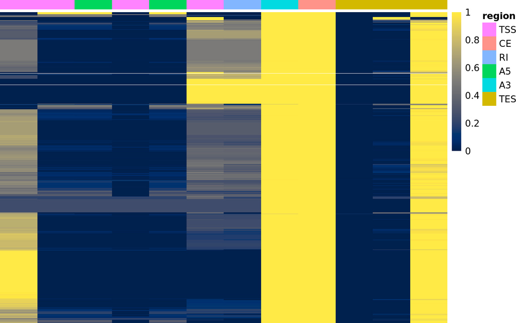

```r
# Prepare a PSI values matrix and remove cells with no CAV1 expression
psi_matrix <- as.matrix(t(assay(se_psi, "psi")))
psi_matrix <- psi_matrix[rowSums(psi_matrix) > 0,]
# Prepare a heatmap column annotations data frame
col_anno_df <- rowData(se_psi) %>%
    as.data.frame %>%
    dplyr::transmute(region = factor(
        type, levels = c("TSS", "CE", "RI", "A5", "A3", "TES")
    ))
# Plot the PSI value heatmap
pheatmap::pheatmap(
    mat = psi_matrix,
    annotation_col = col_anno_df,
    color = viridis::cividis(100),
    cluster_rows = TRUE, cluster_cols = FALSE,
    show_rownames = FALSE, show_colnames = FALSE,
    treeheight_row = 0, annotation_names_col = FALSE
)
```

Plot the CAV1 transcript structures:

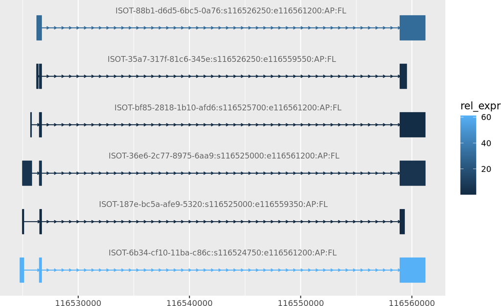

```r
# Calculate the relative expression of transcripts based on overall TPM values
# across all cells
tx_tpm_sums <- rowSums(assay(sce_transcript, "tpm"))
tx_rel_exprs <- tx_tpm_sums / sum(tx_tpm_sums) * 100
# Prepare the GenomicRangesList object for visualization
tx_granges_list <- rowRanges(sce_transcript)
tx_granges_list <- unlist(tx_granges_list)
mcols(tx_granges_list)$type <- "exon"
mcols(tx_granges_list)$rel_expr <- tx_rel_exprs[names(tx_granges_list)]
tx_granges_list <- split(tx_granges_list, names(tx_granges_list))
# Plot the transcript structures
ggbio::autoplot(
    tx_granges_list,
    ggplot2::aes(type = type, col = rel_expr, fill = rel_expr)
)
```

Plot the CAV1 transcript structures with introns shrinked to max 1000 bp:

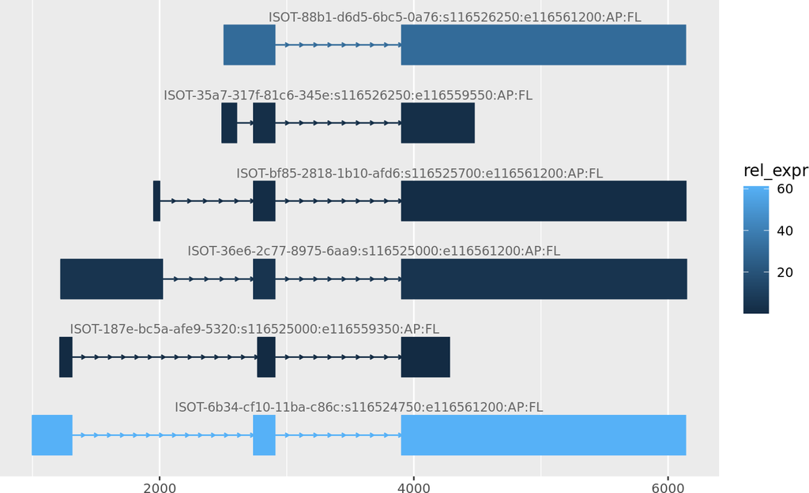

```r
# Prepare the shrinkage function
shrink_func <- biovizBase::shrinkageFun(
    IRanges::gaps(unlist(tx_granges_list)), max.gap = 1000
)
# Prepare the shrinked GenomicRangesList object for visualization
shrink_granges_list <- S4Vectors::endoapply(tx_granges_list, function(gr) {
  gr <- shrink_func(gr)
  mcols(gr)$.ori <- NULL
  return(gr)
})
# Plot the transcript structures
ggbio::autoplot(
    shrink_granges_list,
    ggplot2::aes(type = type, col = rel_expr, fill = rel_expr)
)
```

## 6.1 PSI UMAP plots

```r
# Calculate UMAP coordinates based on PSI values
sce_psi <- as(se_psi, "SingleCellExperiment")
reducedDim(sce_psi, "UMAP") <- reducedDim(sce_transcript, "UMAP")
sce_psi <- sce_psi[
    , colSums(assay(sce_psi, "psi")) > 0
]
# Create UMAP plots colored by PSI values for each gene region
for (region_id in rownames(sce_psi)) {
    cat("\n\n### ", region_id, "\n")
    umap_plot <- dittoSeq::dittoDimPlot(
        sce_psi, region_id, size = 1,
        min.color = "#0072B2", max.color = "#F0E442",
        order = "increasing"
    )
    print(umap_plot)
}
```

### 6.1.1 ENSG00000105974:7:116524750:+:TSS

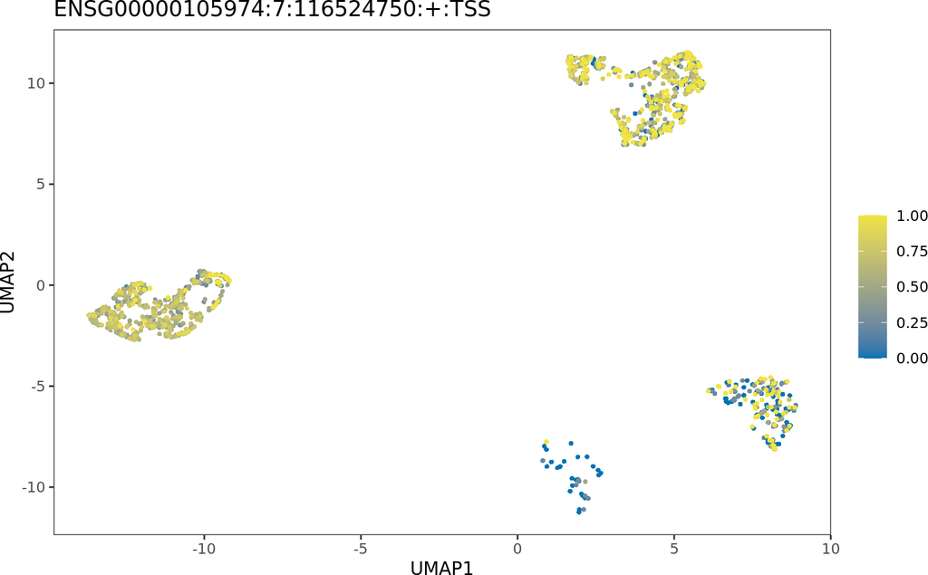

### 6.1.2 ENSG00000105974:7:116525000:+:TSS

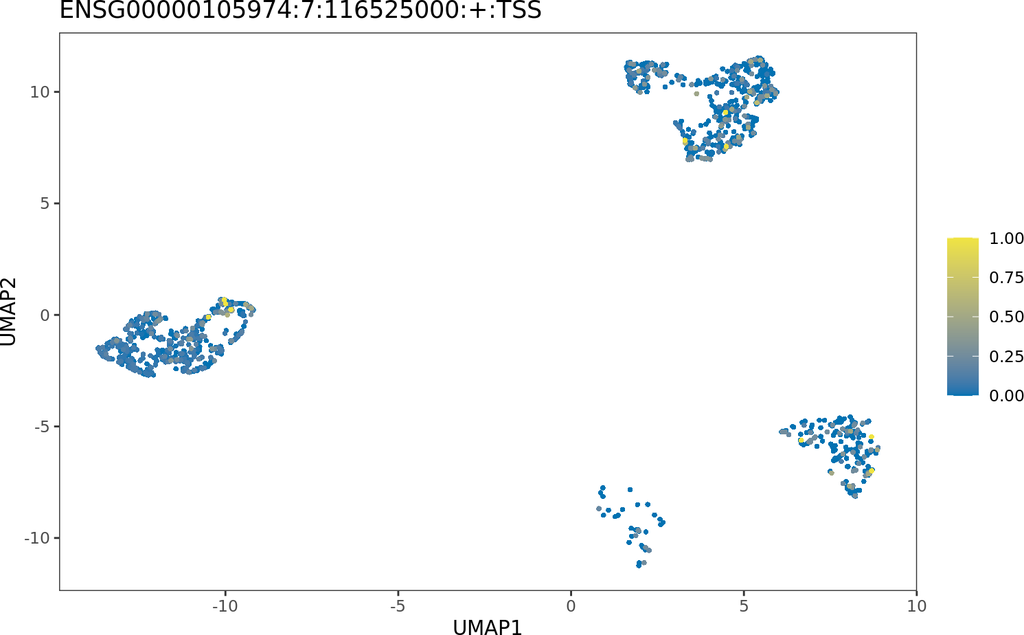

### 6.1.3 ENSG00000105974:7:116525093-116525783:+:A5

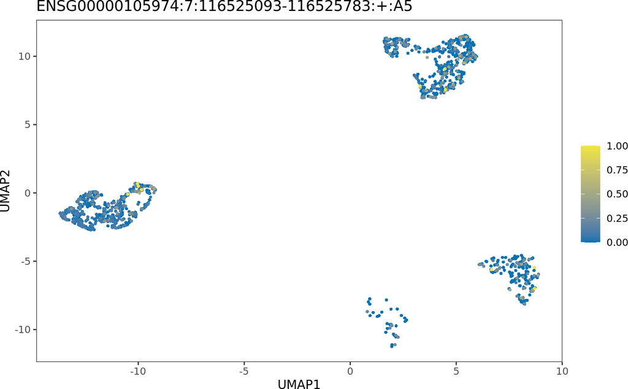

### 6.1.4 ENSG00000105974:7:116525700:+:TSS

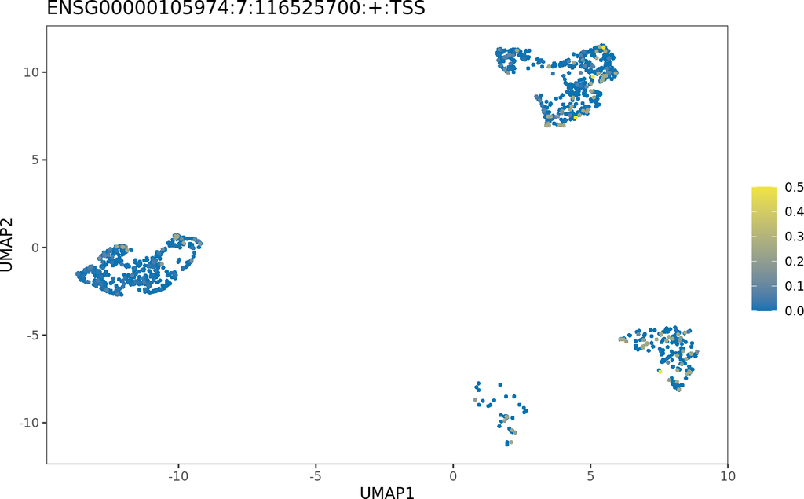

### 6.1.5 ENSG00000105974:7:116525784-116525805:+:A5

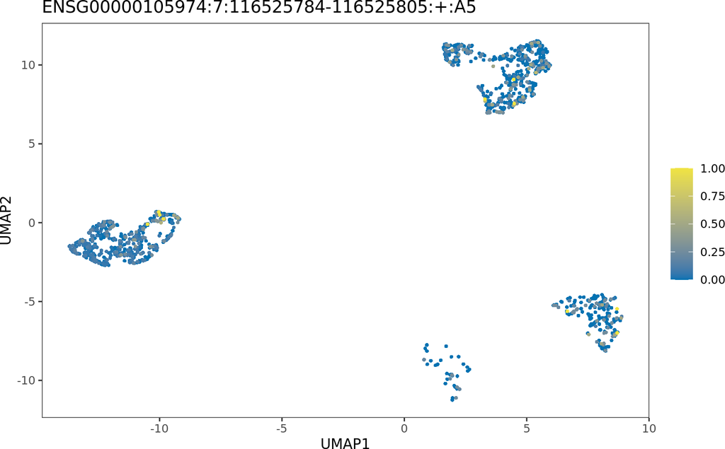

### 6.1.6 ENSG00000105974:7:116526250:+:TSS

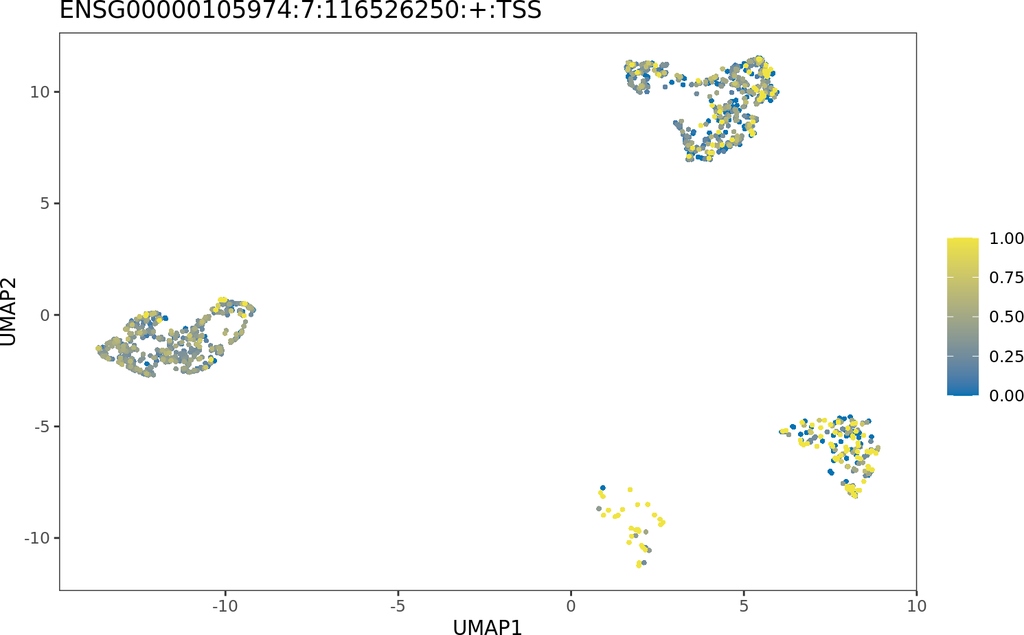

### 6.1.7 ENSG00000105974:7:116526389-116526524:+:RI

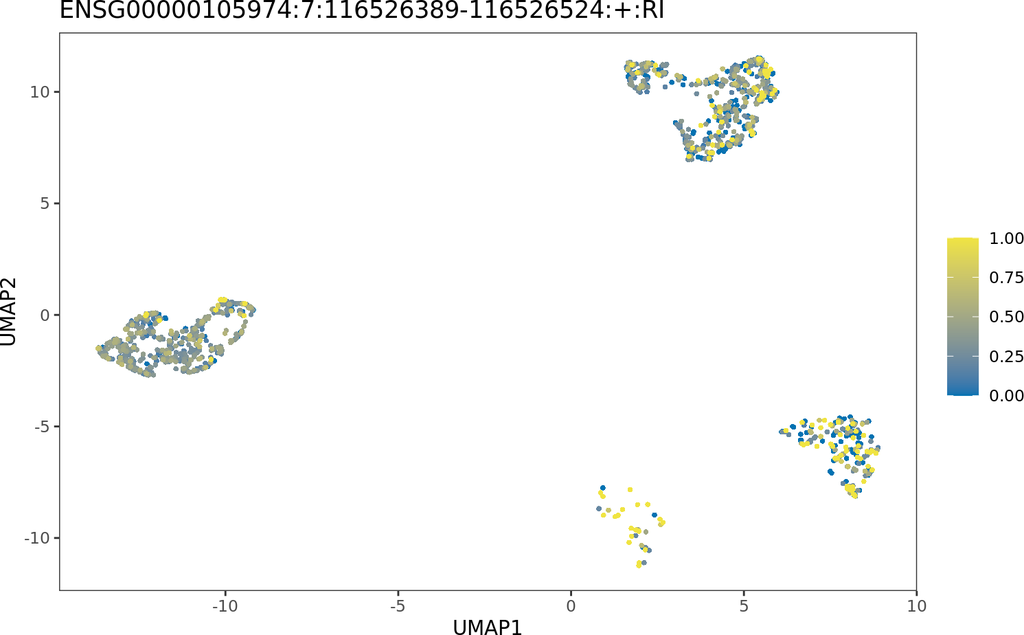

### 6.1.8 ENSG00000105974:7:116526525-116526557:+:A3

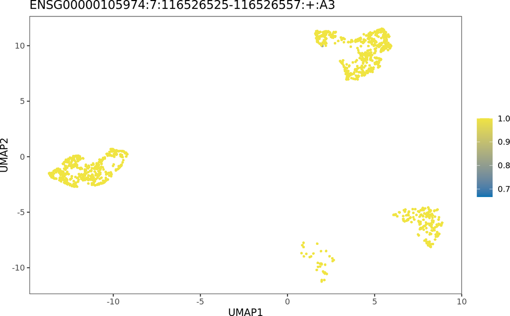

### 6.1.9 ENSG00000105974:7:116526558-116526689:+:CE

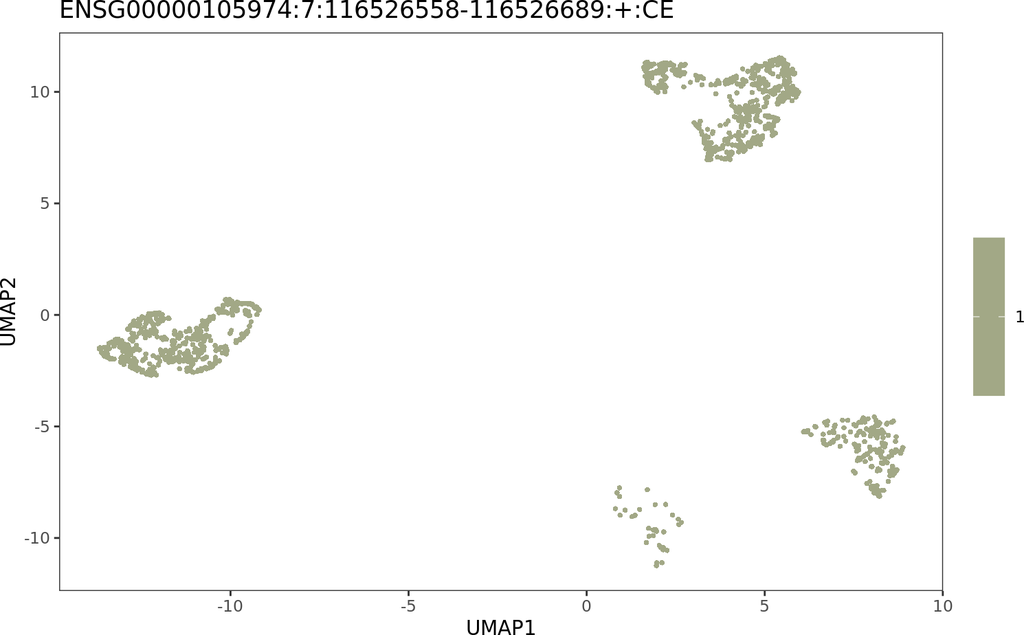

### 6.1.10 ENSG00000105974:7:116559350:+:TES

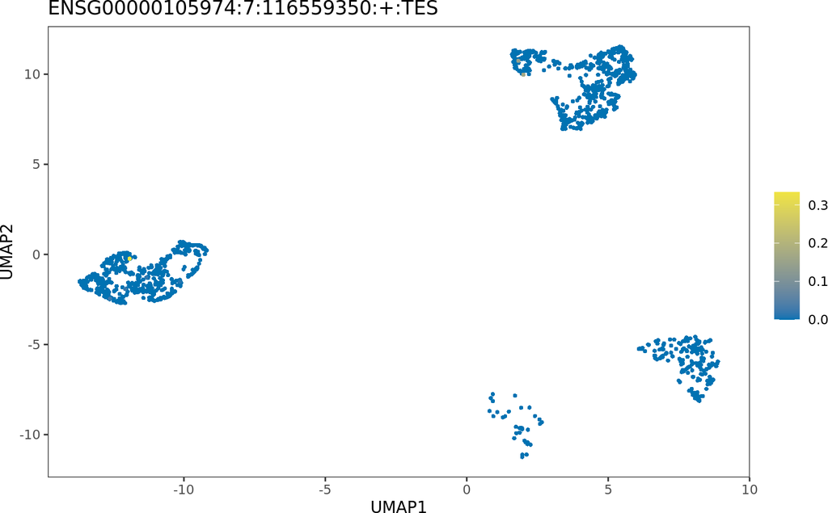

### 6.1.11 ENSG00000105974:7:116559550:+:TES

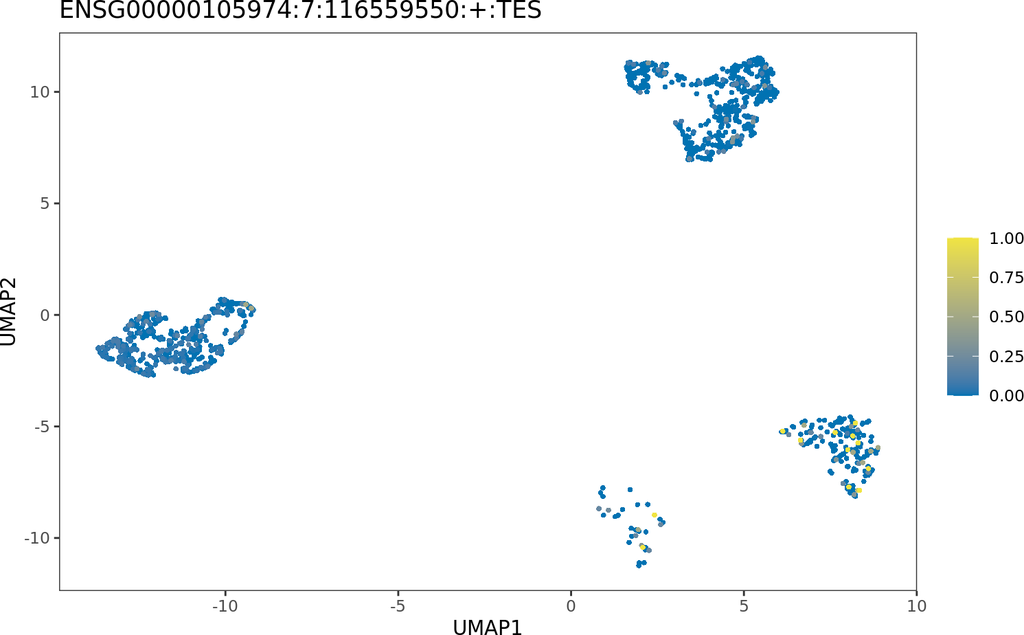

### 6.1.12 ENSG00000105974:7:116561200:+:TES

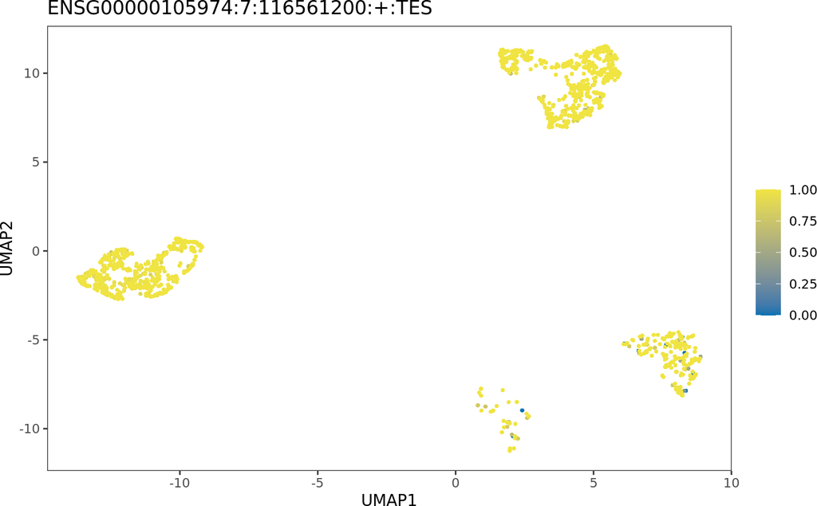